# Resampling: Test de permutación, Simulación de Monte Carlo y Bootstrapping

# Bootstrapping para variables cualitativas (proporciones)

A la hora de comparar variables cualitativas (proporciones), si se cumplen una serie de condiciones, se pueden emplear métodos basados en el teorema del límite central.

- Independencia: El muestreo es aleatorio y el tamaño de la muestra es menor que el 10% de la población.
- Tamaño y distribución: Debe haber al menos 10 eventos verdaderos y 10 eventos falsos esperados dada la hipótesis nula. Esto implica que en el cálculo hay que emplear el null value de *p* establecido en $H_0$. $np_0 >= 10$ , $n(1-p_0) >= 10$.

Si estas condiciones no se satisfacen, la aproximación mediante el teorema del límite central no es válida. En estos casos es posible calcular el *p-value* mediante *bootstrapping*.

## Ejemplo

*El porcentaje de complicaciones que ocurren en una prueba clínica con el instrumental que tiene un hospital es del 10%. Una compañía considera que su instrumental consigue minimizar el riesgo de complicaciones argumentando que solo 3 intervenciones de las 62 realizadas han tenido complicaciones. ¿Hay evidencias de que sea cierto que su instrumental es mejor, utilizando un límite de significancia del 5%?*

**Hipótesis**

Las hipótesis que se pretenden contrastar son:

- $H_0$: No existe una asociación entre el nuevo instrumental y el indice de complicaciones. El valor *p* del nuevo instrumental es igual al del instrumento actual, *p = 0.1*.
- $H_a$: Con el nuevo instrumental se consigue reducir el porcentaje de complicaciones *p < 0.1*.

**Estadístico**

Se calcula el valor de la proporción en la muestra $\hat{p} = 3/62 = 0.0483871$

**Condiciones para solucionarlo mediante el teorema del límite central**

- Independencia: El muestreo es aleatorio y el tamaño de la muestra es menor que el 10% de la población.
- Tamaño y distribución: Debe haber en la muestra al menos 10 eventos verdaderos y 10 eventos falsos dada la hipótesis nula.
- $np_0$ = 62 x 0.1 = 6.2 *no se cumple la condición*
- $n(1-p_0)$ = 62 x 0.9 = 55.8

Al no cumplirse las condiciones, no se puede considerar que $\hat{p}$ se distribuye de forma normal por lo que no se pueden aplicar test paramétricos. Para poder saber cual es la probabilidad de que siendo $H_0$ cierta (*p = 0.1*) de 62 eventos solo 3 o menos sean positivos, es decir, de que $\hat{p}$ = 0.0483871, se pueden recurrir a *bootstrapping.*

**Distribución de bootstrapping**

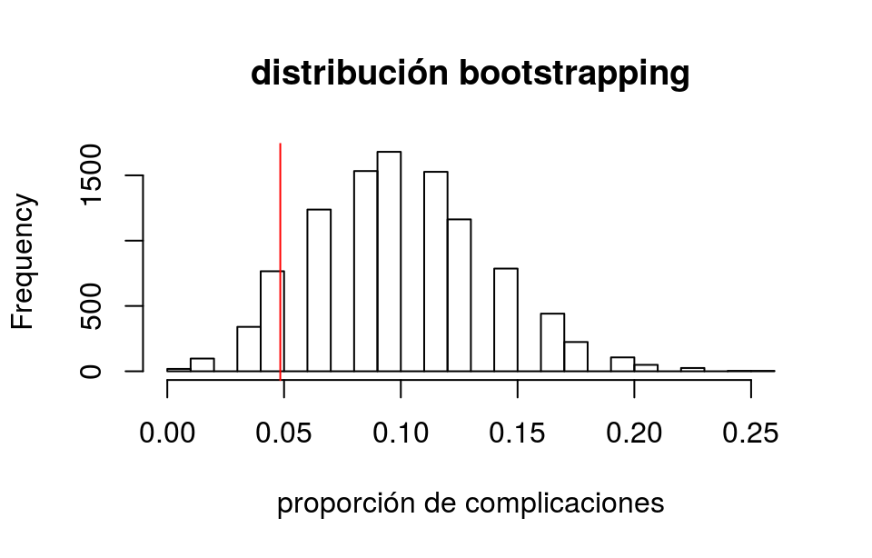

```r
boot_distribution <- rep(NA, 9999)
# La muestra tiene un 10% de true. Esto equivale a la Ho
muestra_original <- c(rep(TRUE, 10), rep(FALSE, 90))

for (i in 1:9999) {
    boot_muestra <- sample(muestra_original, 62, replace = TRUE)
    # Hacer la media de un vector lógico es como calcular la proporción de True
    boot_distribution[i] <- mean(boot_muestra)
}

hist(boot_distribution, breaks = 30,
     main = "distribución bootstrapping",
     xlab = "proporción de complicaciones")
abline(v = 0.0483871, col = "red")
```

**Cálculo de p-value**

El *p-value* es igual a la proporción de simulaciones en las que el valor $\hat{p}$ es menor que el $p$ observado.

```r
sum(boot_distribution <= 0.0483871) / 9999
```

```
## [1] 0.1221122
```

**Conclusión**

Dado que *p-value* es mayor que $\alpha = 0.05$, no hay evidencias suficientes para considerar que los resultados que muestra la compañía no se puedan obtener por fluctuaciones aleatorias siendo la verdadera probabilidad de complicaciones del 10%.

# Test de permutaciones para variables cualitativas (proporciones)

*Un estudio quiere determinar si un fármaco reduce el riesgo de muerte tras una intervención del corazón. Se diseña un experimento en el que pacientes que tienen que ser operados se distribuyen aleatoriamente en dos grupos (control y tratamiento). En vista de los resultados, ¿Se puede decir que el fármaco es efectivo para un nivel de significancia del 5%?*.

| grupo | vivo | muerto | total |
| --- | --- | --- | --- |
| control | 11 | 39 | 50 |
| tratamiento | 14 | 26 | 40 |
| ———– | —- | —— | —– |
| total | 25 | 65 | 90 |

**Hipótesis**

- $H_0$: El porcentaje de supervivencia es independiente del tratamiento, la proporción de vivos es la misma en ambos grupos, *p(control) - p(tratamiento) = 0*.
- $H_a$: El porcentaje de supervivencia es dependiente del tratamiento, *p(control) - p(tratamiento) != 0*.

**Estadístico**

$\hat{p}(control)$ - $\hat{p}(tratamiento)$ = 11/50 - 14/40 = -0.13

**Cálculo de $p_{pool}$**

Siendo $p_{pool} = \frac{total \ positivos}{total \ eventos} = \frac{positivos1 + positivos2}{n1 + n2}$

$p_{pool}$ = (11 + 14)/(50+40) = 0.278

**Condiciones para solucionarlo mediante el teorema del límite central**

Independencia:

- Dentro de cada muestra: El muestreo debe ser aleatorio y el tamaño de la muestra menor que el 10% de la población.
- Entre grupos/muestras: los datos no pueden ser parados.

Tamaño y distribución:

- $n_1p_{pool}$ & $n_1(1-p_{pool})$ = 13.9, 36.1 >= 10 Al menos 10 eventos positivos y negativos esperados en la muestra 1.
- $n_2p_{pool}$ & $n_(1-p_{pool})$= 11.12, 28.88 >= 10 Al menos 10 eventos positivos y negativos esperados en la muestra 2.

A pesar de que las condiciones se cumplen, están muy cerca del límite, por lo que la aproximación por teorema del límite central puede no ser del todo precisa.

*Cálculo de p-value mediante test de permutaciones**

Mediante *permutaciones* se puede estimar la distribución muestral de *p(control) - p(tratamiento)*. Acorde a la $H_0$, la probabilidad de supervivencia en la misma en ambos grupos, para simular esto, se redistribuyen aleatoriamente (manteniendo el tamaño de cada grupo) los sujetos y se calcula la diferencia de proporciones. De los 90 individuos hay 50 control y 40 tratados.

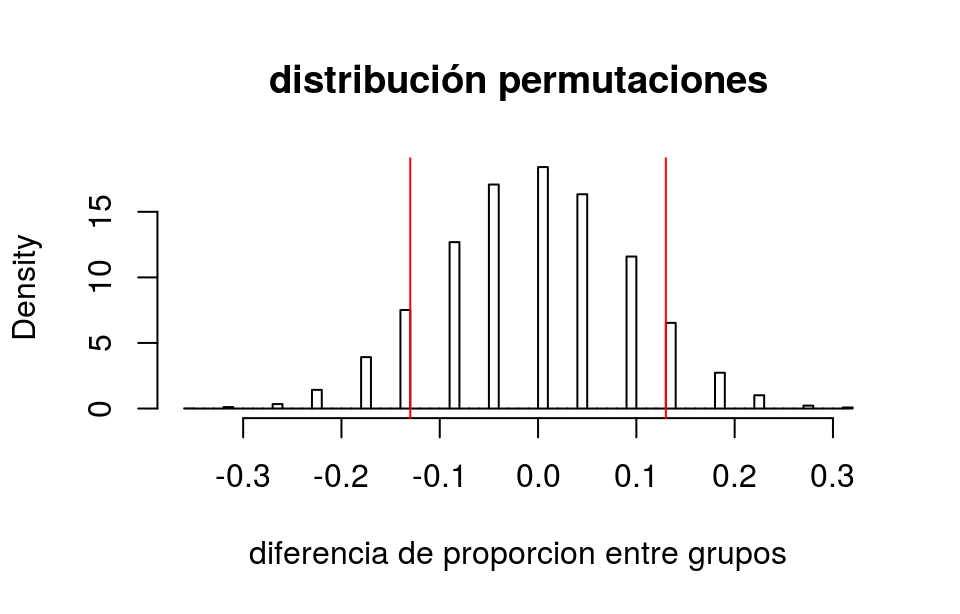

```r
total_individuos <- c(rep(TRUE, 25), rep(FALSE, 65))
posicion_individuos <- c(1:90)
permutation_distribution <- rep(NA,9999)

for (i in 1:9999) {
    a <- sample(posicion_individuos, 50)
    control <- total_individuos[a]
    # El resto de individuos va al grupo tratamiento
    b <- posicion_individuos[!(posicion_individuos %in% a)]
    tratamiento <- total_individuos[b]

    # La media de un vector lógico es la proporcion de TRUEs
    permutation_distribution[i] <- mean(control) - mean(tratamiento)
}

hist(permutation_distribution,breaks = 50, freq = FALSE ,
     main = "distribución permutaciones",
     xlab = "diferencia de proporcion entre grupos")
abline(v = -0.13, col = "red")
abline(v = 0.13, col = "red")
```

El *p-value* es igual al número de permutaciones en las que el valor de *p* calculado es menor igual a -0.13 o mayor igual a 0.13, dividido por el número total permutaciones.

```r
mean(permutation_distribution >=0.13 | permutation_distribution <= -0.13)
```

```
## [1] 0.1637164
```

**Conclusión**

Dado que *p-value* es mayor que el nivel de significancia $(\alpha = 0.05)$, no hay evidencias suficientes para considerar que los resultados muestren una relación entre el tratamiento y la proporción de supervivientes.

# Bibliografía

*Comparing groups Randomization and Bootstrap Methods using R. Andrew S.Zieffler*

*Bootstrap Methods and Permutation Test by Tim Hestemberg*

*Introduction to Statistical Learning, Gareth James, Daniela Witten, Trevor Hastie and Robert Tibshirani*

*The RBook Michael J Crawley*

This work by Joaquín Amat Rodrigo is licensed under a [Creative Commons Attribution 4.0 International License](http://creativecommons.org/licenses/by/4.0/).